# Visual analytics of hotel bookings data

Julià Minguillón

2024-08-12

NOTA: este tutorial usa R + RStudio + ciertas librerías (packages) de R para mostrar el uso de visualizaciones de datos para inspeccionar y analizar un conjunto de datos. Os recomendamos explorar los siguientes enlaces:

1. RStudio: https://posit.co/downloads/
2. ggplot2: https://ggplot2.tidyverse.org/
3. extensiones: https://exts.ggplot2.tidyverse.org/gallery/

## Cargar packages necesarios

```r
#install.packages("ggstatsplot")
```

```r
library("ggmosaic")
library("ggplot2")
library("fitdistrplus")
library("MASS")
library("survival")
library("ggstatsplot")
library("tidyverse")
```

# Data loading and dimensions (N x M)

Leemos el fichero de datos en formato CSV, tiene 119,390 filas y 32 columnas:

```r
x=read.csv("hotel_bookings.csv", stringsAsFactors = T)
dim(x)
```

```
## [1] 119390     32
```

# Data cleaning

Primero inspeccionaremos los datos usando la función summary() incluída en R. La explicación de cada variable se puede encontrar en el artículo en el cual se describe este conjunto de datos de forma detallada, aunque los nombres de las variables son casi auto-explicativos:

```
##           hotel        is_canceled       lead_time   arrival_date_year
##  City Hotel  :79330   Min.   :0.0000   Min.   :  0   Min.   :2015
##  Resort Hotel:40060   1st Qu.:0.0000   1st Qu.: 18   1st Qu.:2016
##                       Median :0.0000   Median : 69   Median :2016
##                       Mean   :0.3704   Mean   :104   Mean   :2016
##                       3rd Qu.:1.0000   3rd Qu.:160   3rd Qu.:2017
##                       Max.   :1.0000   Max.   :737   Max.   :2017
##
##  arrival_date_month arrival_date_week_number arrival_date_day_of_month
##  August :13877      Min.   : 1.00            Min.   : 1.0
##  July   :12661      1st Qu.:16.00            1st Qu.: 8.0
##  May    :11791      Median :28.00            Median :16.0
##  October:11160      Mean   :27.17            Mean   :15.8
##  April  :11089      3rd Qu.:38.00            3rd Qu.:23.0
##  June   :10939      Max.   :53.00            Max.   :31.0
##  (Other):47873
##  stays_in_weekend_nights stays_in_week_nights     adults
##  Min.   : 0.0000         Min.   : 0.0         Min.   : 0.000
##  1st Qu.: 0.0000         1st Qu.: 1.0         1st Qu.: 2.000
##  Median : 1.0000         Median : 2.0         Median : 2.000
##  Mean   : 0.9276         Mean   : 2.5         Mean   : 1.856
##  3rd Qu.: 2.0000         3rd Qu.: 3.0         3rd Qu.: 2.000
##  Max.   :19.0000         Max.   :50.0         Max.   :55.000
##
##     children           babies                 meal          country
##  Min.   : 0.0000   Min.   : 0.000000   BB       :92310   PRT    :48590
##  1st Qu.: 0.0000   1st Qu.: 0.000000   FB       :  798   GBR    :12129
##  Median : 0.0000   Median : 0.000000   HB       :14463   FRA    :10415
##  Mean   : 0.1039   Mean   : 0.007949   SC       :10650   ESP    : 8568
##  3rd Qu.: 0.0000   3rd Qu.: 0.000000   Undefined: 1169   DEU    : 7287
##  Max.   :10.0000   Max.   :10.000000                     ITA    : 3766
##  NA's   :4                                               (Other):28635
##        market_segment  distribution_channel is_repeated_guest
##  Online TA    :56477   Corporate: 6677      Min.   :0.00000
##  Offline TA/TO:24219   Direct   :14645      1st Qu.:0.00000
##  Groups       :19811   GDS      :  193      Median :0.00000
##  Direct       :12606   TA/TO    :97870      Mean   :0.03191
##  Corporate    : 5295   Undefined:    5      3rd Qu.:0.00000
##  Complementary:  743                        Max.   :1.00000
##  (Other)      :  239
```

[output cut: 25 more lines]

```
##  Min.   :  -6.38   Min.   :0.00000             Min.   :0.0000
##  1st Qu.:  69.29   1st Qu.:0.00000             1st Qu.:0.0000
##  Median :  94.58   Median :0.00000             Median :0.0000
##  Mean   : 101.83   Mean   :0.06252             Mean   :0.5714
##  3rd Qu.: 126.00   3rd Qu.:0.00000             3rd Qu.:1.0000
##  Max.   :5400.00   Max.   :8.00000             Max.   :5.0000
##
##  reservation_status reservation_status_date
##  Canceled :43017    2015-10-21:  1461
##  Check-Out:75166    2015-07-06:   805
##  No-Show  : 1207    2016-11-25:   790
##                     2015-01-01:   763
##                     2016-01-18:   625
##                     2015-07-02:   469
##                     (Other)   :114477
```

# Variables numéricas

Podemos observar algunos valores extraños para algunas variables, por ejemplo:

1. Un máximo de 55 en adults
2. Un máximo de 10 en children (incluyendo valores perdidos)
3. Un máximo de 10 en babies
4. Valores negativos en el coste promedio por día (adr) o muy elevados

Vamos a visualizar el histograma de la variable adults, indicando al menos 55 intervalos en el histograma, usando la función hist() de R:

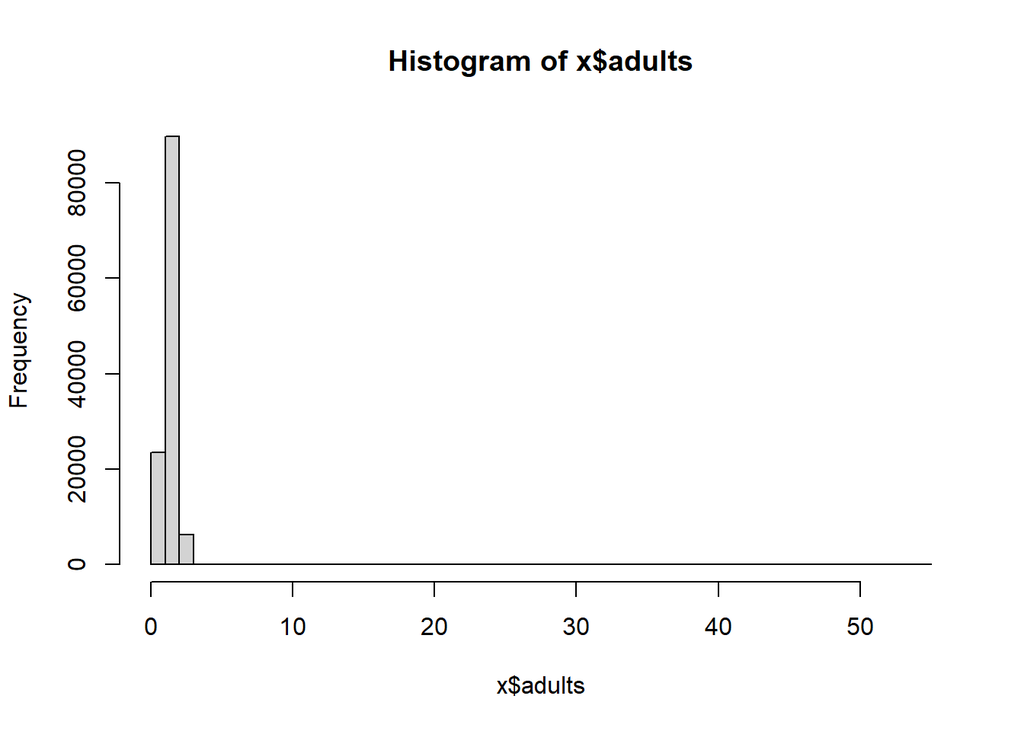

```r
hist(x$adults,breaks=55)
```

Se puede ver que el histograma no muestra ninguna barra alrededor del 55, dado que se trata de un conjunto muy grande y seguramente se tratará solamente de un caso o pocos. En estos casos, para analizar valores extremos de una variable se pueden pintar los valores de la variable en cuestión de la siguiente manera, ordenando los datos (si son numéricos como en este caso):

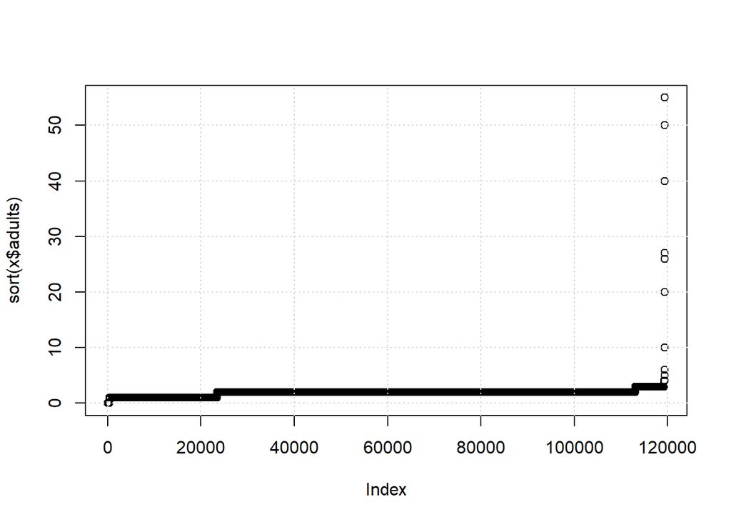

```r
plot(sort(x$adults))
grid()
```

La variable Index es la posición del elemento una vez ordenado, pero nos interesa más el eje Y, ya que podemos ver que hay unos pocos elementos con valores de 10 o superior. Como se trata de una variable entera pero con un conjunto limitado de valores posibles podemos usar table() para verlos:

```r
table(x$adults)
```

```
##
##     0     1     2     3     4     5     6    10    20    26    27    40    50
##   403 23027 89680  6202    62     2     1     1     2     5     2     1     1
##    55
##     1
```

Como se puede ver, hay un caso de una reserva con 10 adultos, dos con 20 adultos, etc., hasta una de 55 adultos! Sin entrar en más consideraciones, eliminaremos todas las filas con reservas de 10 adultos o más:

```r
x=x[x$adults<10,]
```

## EJERCICIO: hacer lo mismo con las variables children y babies

Vamos a visualizar el histograma de la variable children usando la función hist() de R:

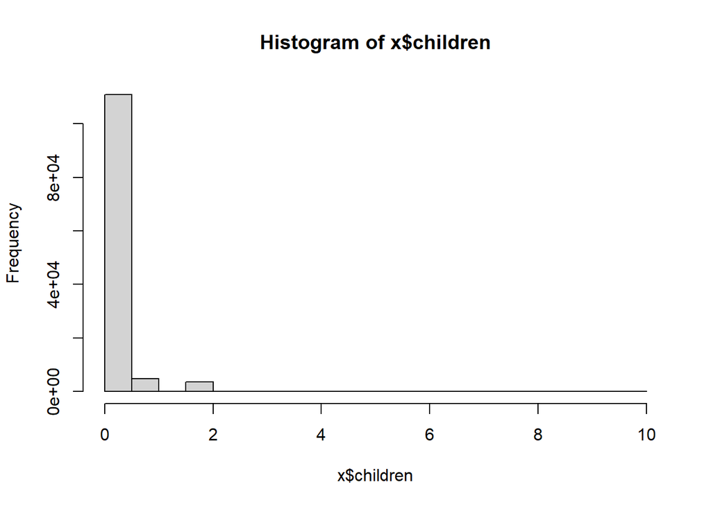

```r
hist(x$children)
```

Se puede ver que el histograma no muestra ninguna barra alrededor del 10, dado que se trata de un conjunto muy grande y seguramente se tratará solamente de un caso o pocos. En estos casos, para analizar valores extremos de una variable se pueden pintar los valores de la variable en cuestión de la siguiente manera, ordenando los datos (si son numéricos como en este caso):

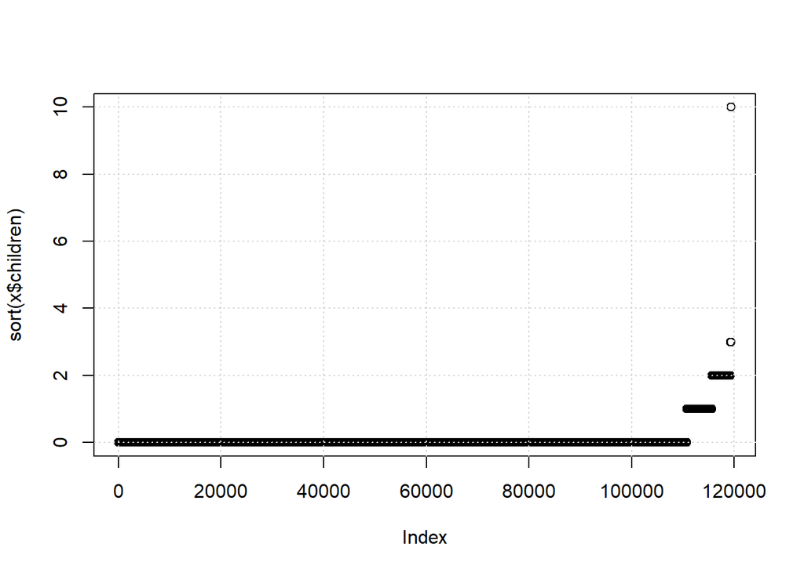

```r
plot(sort(x$children))
grid()
```

La variable Index es la posición del elemento una vez ordenado, pero nos interesa más el eje Y, ya que podemos ver que hay unos pocos elementos con valores de 10 o superior. Como se trata de una variable entera pero con un conjunto limitado de valores posibles podemos usar table() para verlos:

```r
table(x$children)
```

```
##
##      0      1      2      3     10
## 110783   4861   3652     76      1
```

```r
x=x[x$children<10,]
```

Vamos a visualizar el histograma de la variable babies usando la función hist() de R:

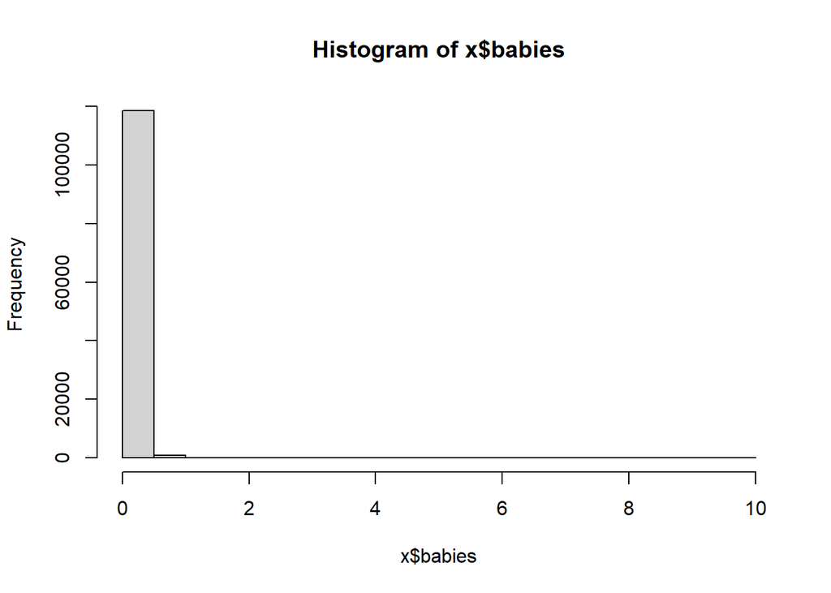

```r
hist(x$babies)
```

Se puede ver que el histograma no muestra ninguna barra alrededor del 10, dado que se trata de un conjunto muy grande y seguramente se tratará solamente de un caso o pocos. En estos casos, para analizar valores extremos de una variable se pueden pintar los valores de la variable en cuestión de la siguiente manera, ordenando los datos (si son numéricos como en este caso):

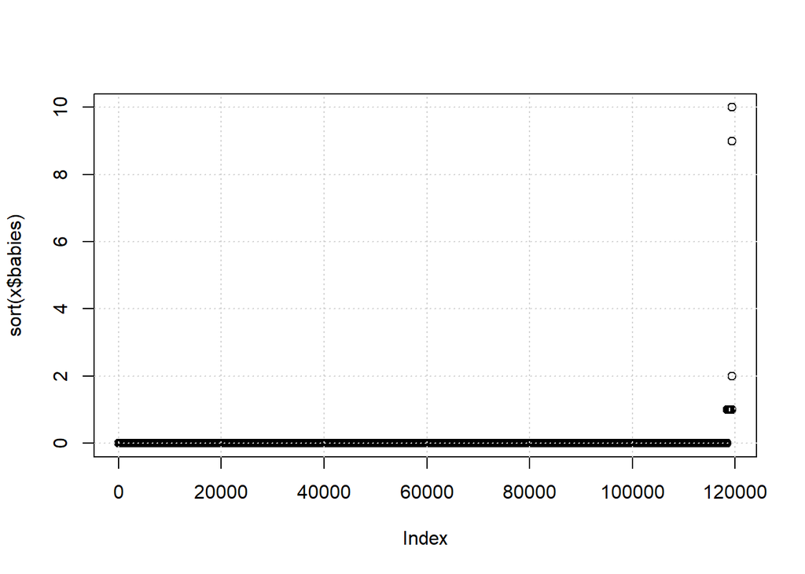

```r
plot(sort(x$babies))
grid()
```

La variable Index es la posición del elemento una vez ordenado, pero nos interesa más el eje Y, ya que podemos ver que hay unos pocos elementos con valores de 10 o superior. Como se trata de una variable entera pero con un conjunto limitado de valores posibles podemos usar table() para verlos:

```r
table(x$babies)
```

```
##
##      0      1      2      9     10
## 118455    900     15      1      1
```

```r
x=x[x$babies<8,]
```

El histograma de la variable adr (gasto medio por día) presenta el mismo problema que el caso de la variable adults, así que directamente haremos un gráfico con los valores ordenados:

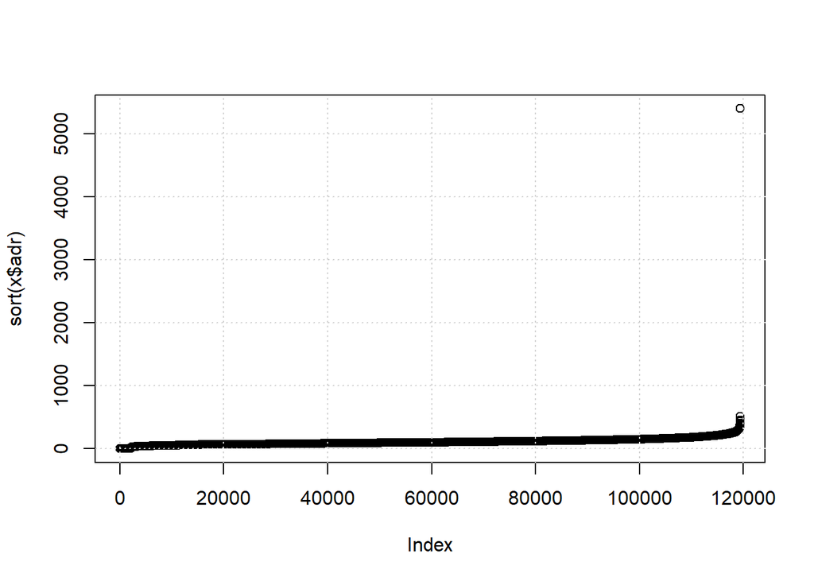

```r
plot(sort(x$adr))
grid()
```

En este caso se ve que hay solamente un valor muy por encima del resto, lo consideramos un outlier y lo eliminamos, así como los valores negativos que no tienen una explicación clara, aunque dejamos los valores 0:

```r
x=x[x$adr>=0 & x$adr<1000,]
x <- x %>% filter(is.finite(adr))
max(x$adr)
```

```
## [1] 510
```

El histograma ahora sí que nos aporta información relevante. Lo dibujamos usando el package ggplot2 que ofrece muchas más opciones que hist():

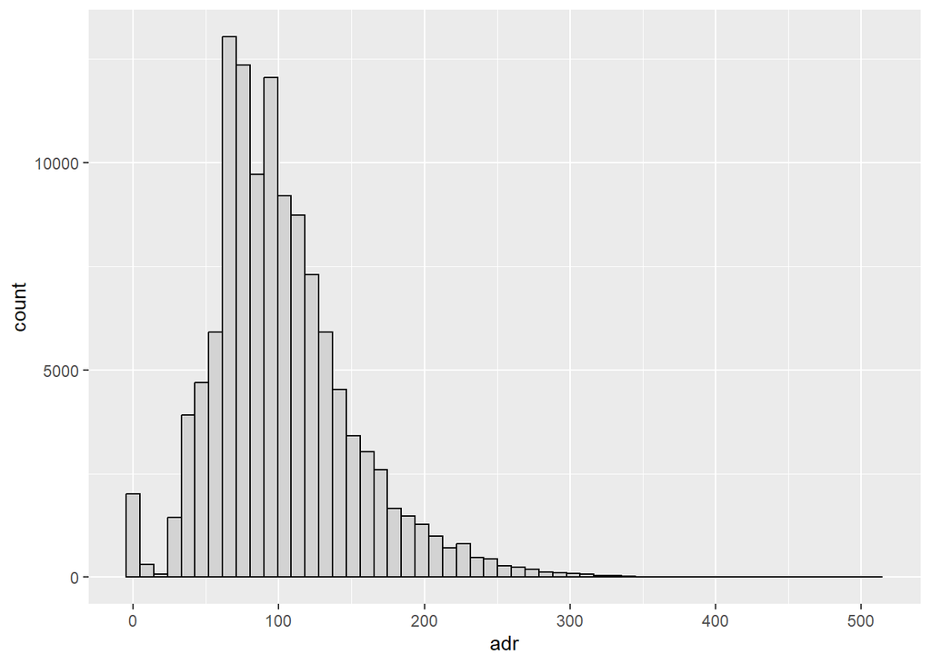

```r
ggplot(data=x, aes(x=adr)) +
  geom_histogram(bins=55, colour="black", fill = "lightgray")
```

## EJERCICIO: retocar el gráfico para que el nombre de los ejes, título, etc. sea el adecuado para una presentación

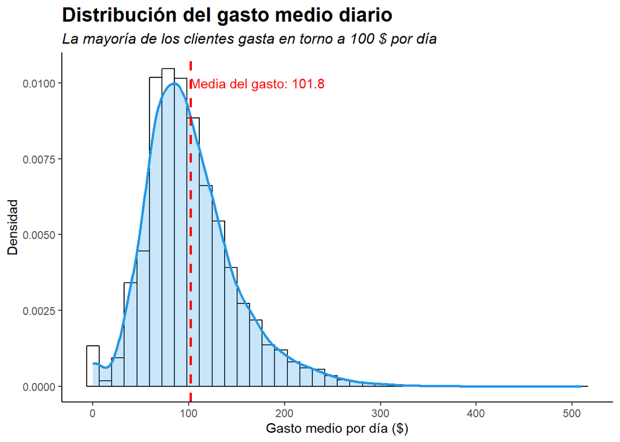

```r
media_adr <- mean(x$adr, na.rm = TRUE)
mediana_adr <- median(x$adr, na.rm = TRUE)

ggplot(data=x, aes(x=adr, after_stat(density))) +
  geom_histogram(bins=40, colour="black", fill = "white") +
  geom_density(size = 1, bw = 10, lwd = 1, colour = 4, fill = 4, alpha = 0.25) +
  geom_vline(aes(xintercept = media_adr), colour = "red", linetype = "dashed", size = 1) +
  annotate("text", x = media_adr + 70, y = 0.01, label = paste("Media del gasto:", round(media_adr, 2)), colour = "red") +
  labs(
    title = "Distribución del gasto medio diario",
    subtitle = "La mayoría de los clientes gasta en torno a 100 $ por día"
  ) +
  theme(
    plot.title = element_text(hjust = 0, size = 16, face = "bold"),
    plot.subtitle = element_text(hjust = 0, size = 12, face = "italic"),
    panel.grid.major = element_blank(),
    panel.grid.minor = element_blank(),
    panel.background = element_blank(),
    axis.line = element_line(colour = "black")) +
  xlab("Gasto medio por día ($)") +
  ylab("Densidad")
```

Podemos ver que hay un conjunto de unos 2000 valores 0, los cuales podrían ser analizados de forma separada, por ejemplo. Existen packages de R que nos pueden ayudar a estimar dicha distribución y los parámetros que la determinan de forma visual, como por ejemplo el package fitdistrplus mediante la función descdist():

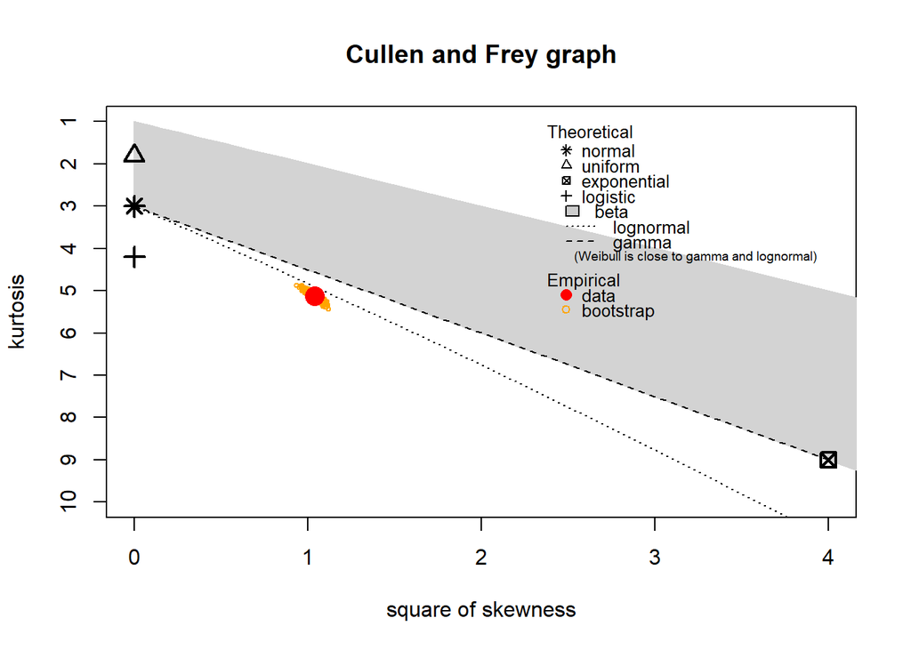

```
## summary statistics
## ------
## min:  0   max:  510
## median:  94.62
## mean:  101.8011
## estimated sd:  48.14287
## estimated skewness:  1.018971
## estimated kurtosis:  5.13332
```

```r
require(fitdistrplus)
descdist(x$adr,boot=1000)
```

De todas formas, con el objetivo de experimentar con un conjunto de datos lo más limpio posible vamos a proceder a:

1. eliminar las estancias de 0 días
2. eliminar las estancias a coste 0
3. eliminar las estancias sin personas
4. substituir los NA de la variable children por 0

```r
x[is.na(x$children),'children']=0
x=x[x$adr>0 & (x$stays_in_week_nights+x$stays_in_weekend_nights)>0 & (x$adults+x$children+x$babies)>0 & !is.na(x$children),]
```

# Variables categóricas

Por lo que respecta a las variables categóricas, la función summary() ya nos da una primera idea de los valores posibles que puede coger cada una. Por ejemplo, en el conjunto original (antes de eliminar outliers) hay 79,330 reservas en un hotel de ciudad (Lisboa) y 40,060 en un resort (el Algarve). Podemos preguntarnos si la distribución del coste es la misma para ambos grupos, ya sea mediante el test estadístico adecuado o simplemente comparando histogramas, en este caso usando el package ggplot2 mucho más potente para crear gráficos de todo tipo:

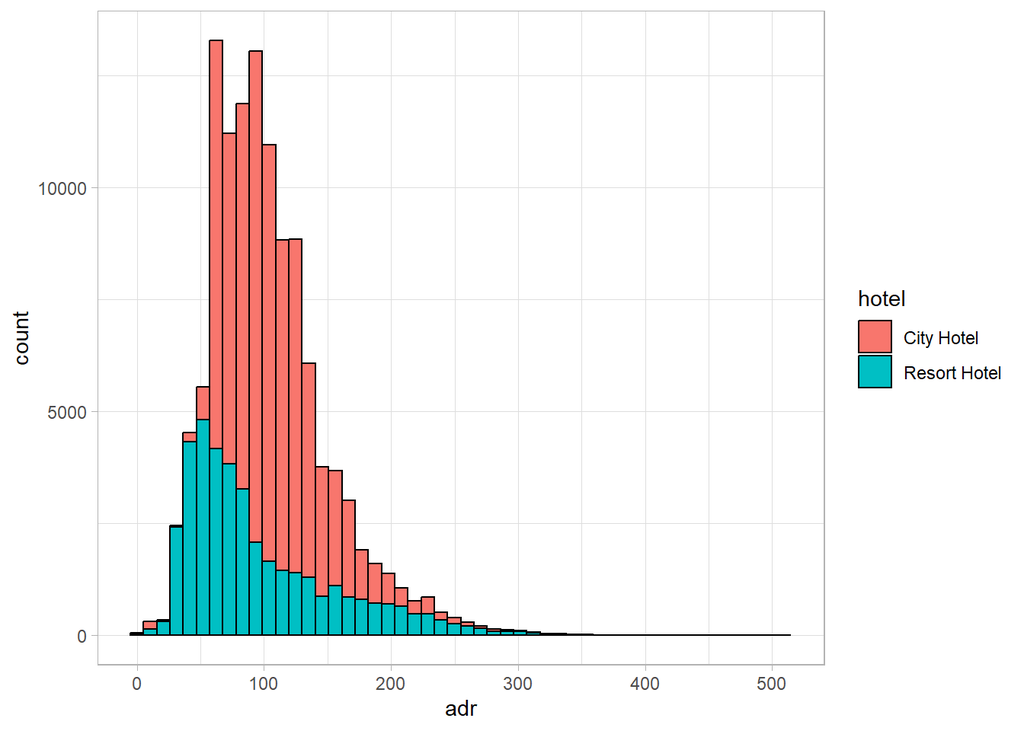

```r
require(ggplot2)
ggplot(data=x, aes(x=adr, fill=hotel)) +
  geom_histogram(bins=50, colour="black") +
  theme_light()
```

Se puede observar que los precios en Lisboa (City Hotel) más típicos están ligeramente a la derecha de los más típicos en el Algarve (Resort Hotel), aunque en cambio los precios más altos en Lisboa decrecen más rápido que en el Algarve. Con un plot de tipo violin podremos ver más detalle, especialmente si también mostramos los cuartiles típicos de un box-plot:

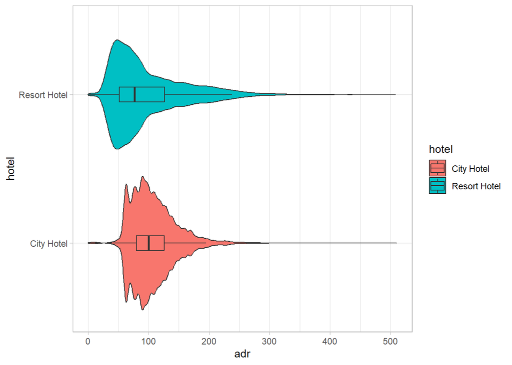

```r
ggplot(data=x, aes(x=hotel, y=adr, fill=hotel)) +
  geom_violin() + geom_boxplot(width=.1, outliers = F) +
  coord_flip() +
  theme_light()
```

Existe un package de R llamado ggstatsplot que dispone de funciones específicas para cada tipo de gráfico, incluyendo también los tests estadísticos adecuados para establecer si existen diferencias entre grupos:

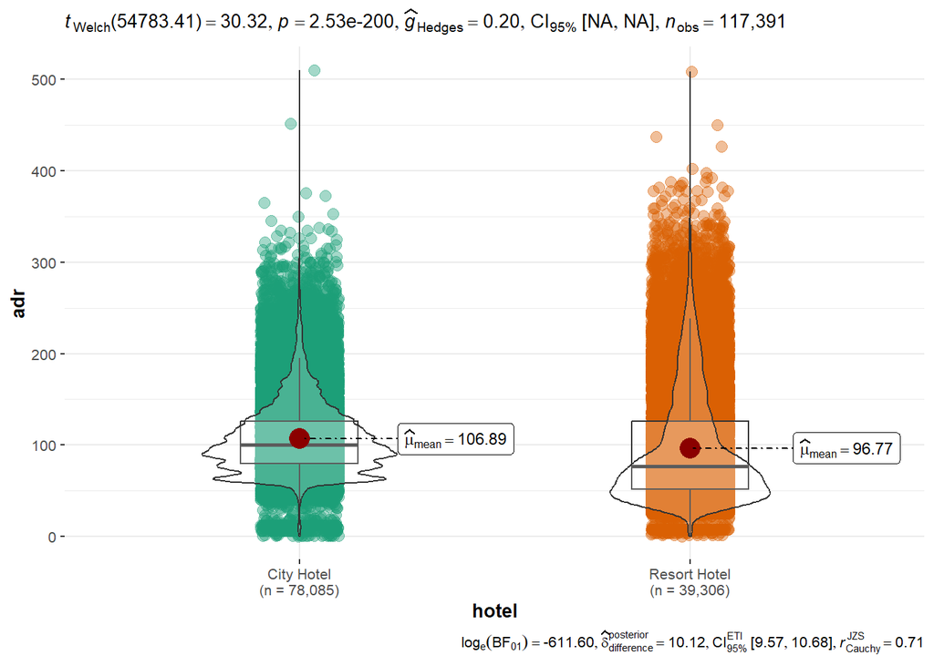

```r
require(ggstatsplot)
ggbetweenstats(data=x, x=hotel, y=adr)
```

Una variable interesante es la procedencia de los clientes del hotel (country). El problema es que es una variable con muchos valores diferentes (178), por lo que debemos quedarnos con los paises que aportan más turistas, mostrando también si escogen hotel de ciudad o resort:

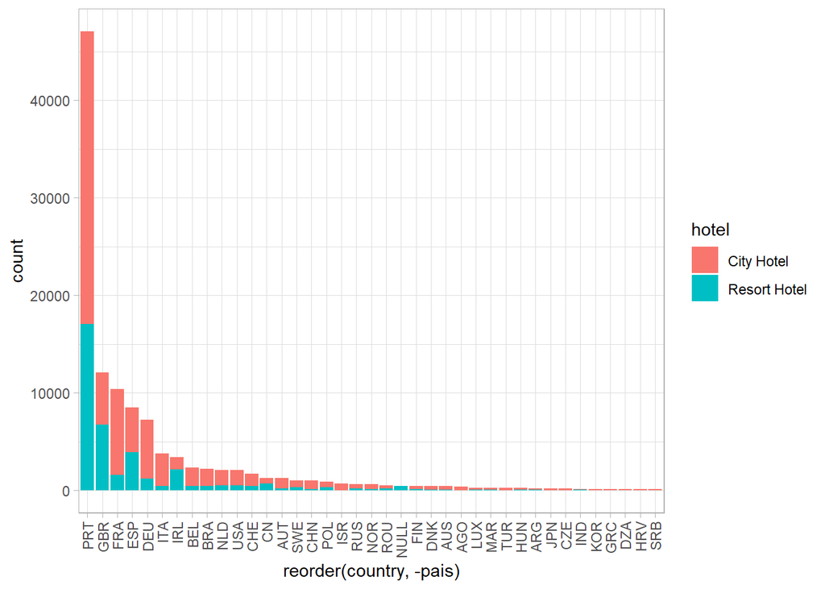

```r
require(tidyverse)
# paises con al menos 100 reservas
xx = x %>% group_by(country) %>% mutate(pais=n()) %>% filter(pais>=100)
xx$country=factor(xx$country)
ggplot(data=xx, aes(x=reorder(country, -pais))) +
  geom_bar(stat="count", aes(fill=hotel)) +
  theme_light() +
  theme(axis.text.x = element_text(angle = 90, vjust = 0.5, hjust=1))
```

Obviamente, Portugal (PRT) ocupa la primera posición destacada, seguida de paises “cercanos”, como Gran Bretaña, Francia y España. Los visitantes de Gran Bretaña e Irlanda optan más por un resort, mientras que los de Francia, Alemania e Italia principalmente visitan la ciudad de Lisboa.

## EJERCICIO: existen diferencias entre los habitantes de Portugal (del país) y el resto (“extranjeros”)?

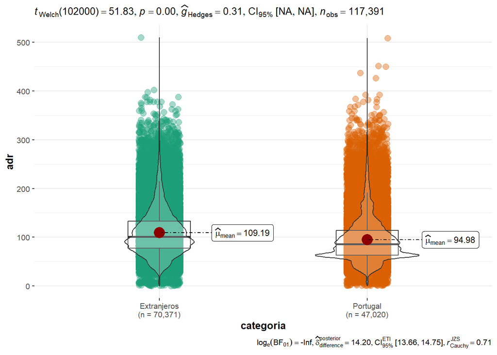

```r
require(ggstatsplot)

x <- x %>%
  mutate(categoria = ifelse(country == "PRT", "Portugal", "Extranjeros"))

ggbetweenstats(data=x, x=categoria, y=adr)
```

Otra de las variables interesantes es is_canceled que nos indica si una reserva fue cancelada o no (un 37.0% de las veces). Podemos ver la relación entre dos variables categóricas usando un gráfico de mosaico:

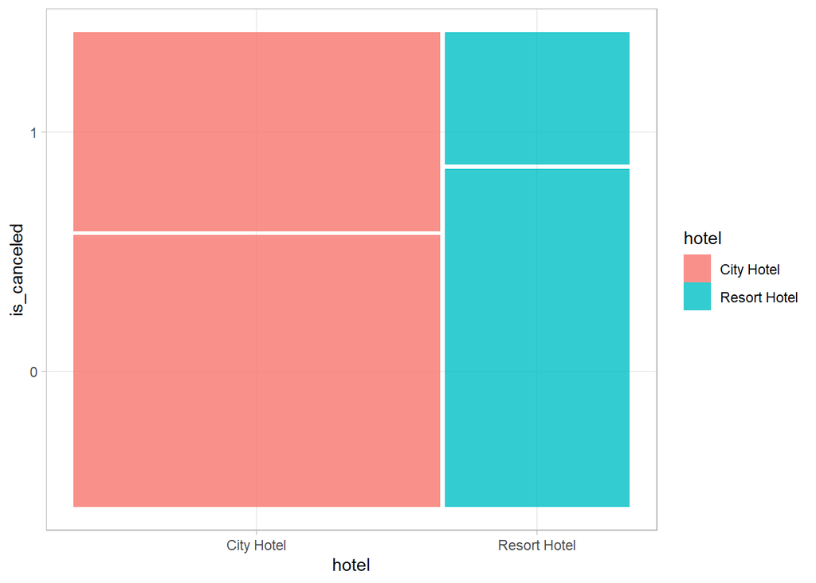

```r
require(ggmosaic)
x$is_canceled=as.factor(x$is_canceled)
ggplot(data=x) +
  geom_mosaic(aes(x=product(is_canceled, hotel), fill=hotel)) +
  theme_light()
```

Se puede observar que el porcentaje de cancelaciones (1 en el eje Y) en un resort es inferior al de un hotel en la ciudad de Lisboa. En el eje X, los tamaños relativos de cada columna se corresponden también con la proporción de cada tipo de hotel. Es importante no pensar en las etiquetas del eje Y (0 / 1) como la propoción numérica real de cancelación, ya que puede llevar a engaño.

En el caso de cancelación por país para los países con más turistas:

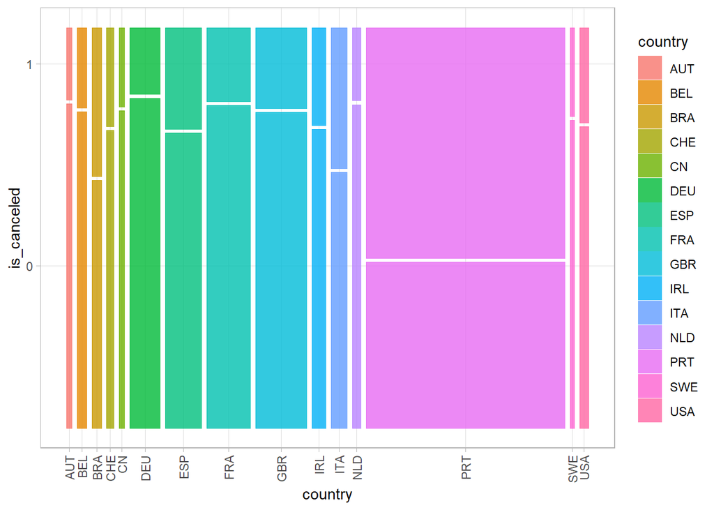

```r
# paises con al menos 1000 reservas
xx = x %>% group_by(country) %>% mutate(pais=n()) %>% filter(pais>=1000)
xx$country=factor(xx$country)
ggplot(data=xx) +
  geom_mosaic(aes(x=product(is_canceled, country), fill=country)) +
  theme_light() +
  theme(axis.text.x = element_text(angle = 90, vjust = 0.5, hjust=1))
```

Se puede comprobar que la tasa de cancelaciones es mucho mayor para los turistas locales (de Portugal, PRT), mientras que es mucho más baja para el resto de paises. No obstante, este gráfico no es de lectura fácil, en este caso no hay ningún orden ni de los paises ni del porcentaje de cancelaciones.

## EJERCICIO: mejorar el gráfico anterior para hacerlo más inteligible, y plantearse si es posible visualizar las relaciones entre tres o más variables de tipo categórico.

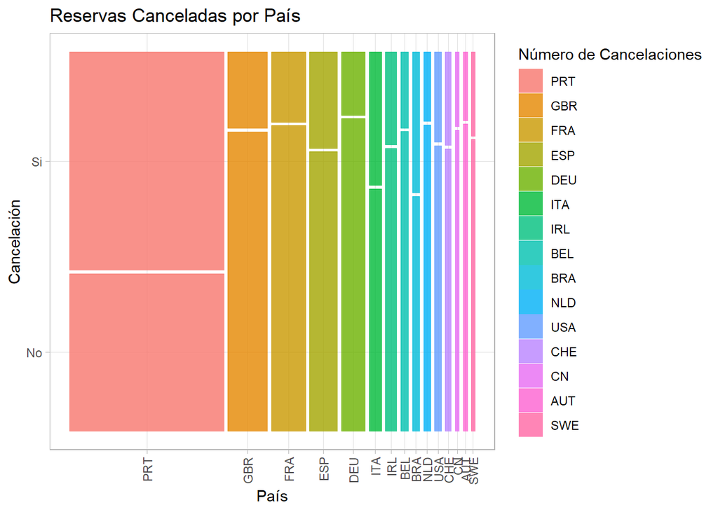

```r
# Filtrar países con al menos 1000 reservas
xx = x %>% group_by(country) %>% mutate(pais=n()) %>% filter(pais >= 1000)
xx$country = factor(xx$country, levels = xx %>% group_by(country) %>% summarise(total = n()) %>% arrange(desc(total)) %>% pull(country))

xx <- xx %>%
  mutate(cancelado = ifelse(is_canceled == "1", "Si", "No"))


# Crear el gráfico de mosaico con colores continuos usando ggmosaic
ggplot(data = xx) +
  geom_mosaic(aes(x = product(cancelado, country), fill = country)) +
  theme_light() +
  theme(axis.text.x = element_text(angle = 90, vjust = 0.5, hjust=1)) +
  labs(title="Reservas Canceladas por País",
       x="País",
       y="Cancelación",
       fill="Número de Cancelaciones")
```

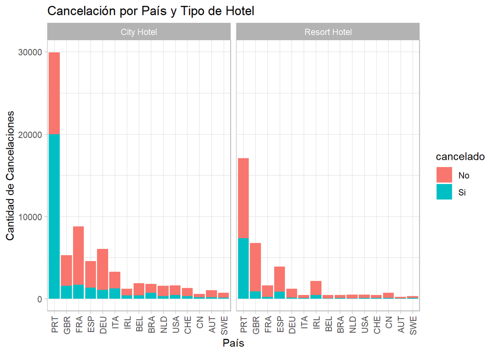

```r
ggplot(xx, aes(x = country, fill = cancelado)) +
  geom_bar() +
  facet_wrap(~ hotel) +
  theme_light() +
  theme(axis.text.x = element_text(angle = 90, vjust = 0.5, hjust=1)) +
  labs(title="Cancelación por País y Tipo de Hotel",
       x="País",
       y="Cantidad de Cancelaciones")
```

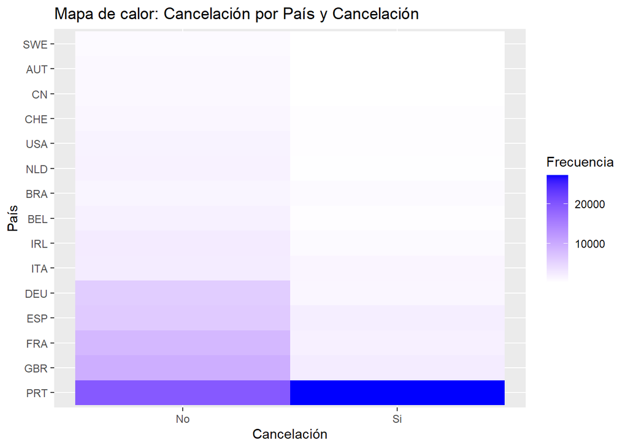

```r
xx %>%
  count(cancelado, country, is_canceled) %>%
  ggplot(aes(x = cancelado, y = country, fill = n)) +
  geom_tile() +
  scale_fill_gradient(low = "white", high = "blue") +
  labs(title="Mapa de calor: Cancelación por País y Cancelación",
       x="Cancelación",
       y="País",
       fill="Frecuencia")
```

Finalmente, vamos a analizar el comportamiento de las reservas con respecto a la fecha de entrada. Primero, usando el package lubridate de R (una maravilla para manipular datos de tipo fecha y hora) crearemos una variable dia para saber qué día de la semana fue la llegada al hotel, y analizaremos cuantas reservas hubo cada día:

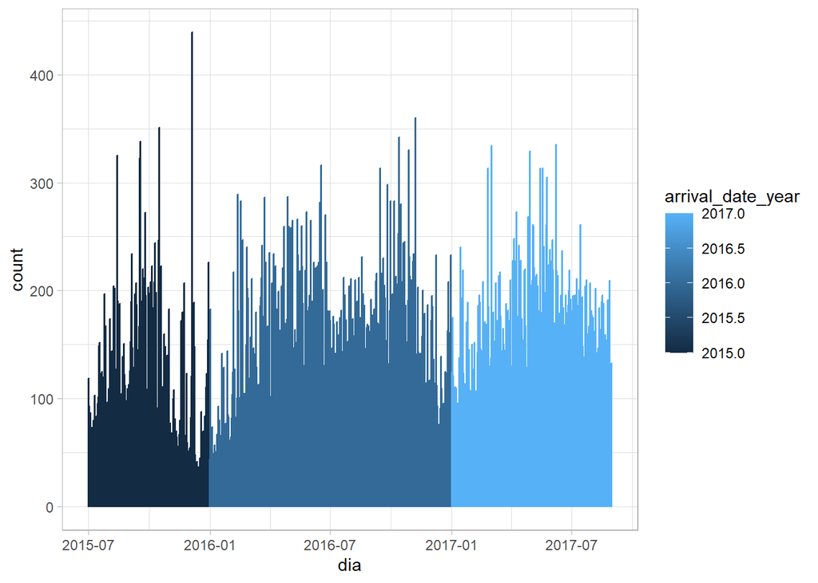

```r
require(lubridate)
x$dia=as_date(paste0(x$arrival_date_year,'-',x$arrival_date_month,'-',x$arrival_date_day_of_month))
ggplot(data=x,aes(x=dia,group=arrival_date_year,color=arrival_date_year)) +
  geom_bar() +
  theme_light()
```

Tal y como describe el artículo, los datos comprenden desde el 1 de Julio de 2015 hasta el 31 de agosto de 2017. Se pueden observar algunos picos que podrían ser interesantes.

## EJERCICIO: mejorar y desdoblar el gráfico anterior por tipo de hotel o por país de orígen.

Con el día calculado, junto con las variables stays_in_week/weekend_nights podemos tratar de categorizar manualmente el tipo de viaje, de acuerdo a los siguientes criterios (arbitrarios, claramente mejorables):

Una manera de refinar esta clasificación sería mirar la cantidad de adultos, niños y bebés para decidir si se trata de una persona viajando por trabajo o bien una familia.

```r
require(lubridate)
x$tipo <- ifelse(x$stays_in_weekend_nights == 0, "work",
          ifelse(x$stays_in_week_nights == 0, "weekend",
          ifelse(x$stays_in_week_nights == 1 & wday(as.POSIXct(x$dia, tz = "UTC")) == 6, "weekend",
          ifelse(x$stays_in_week_nights == 5 & (x$stays_in_weekend_nights == 3 | x$stays_in_weekend_nights == 4), "package",
          ifelse(x$stays_in_week_nights <= 5 & x$stays_in_weekend_nights < 3, "work+rest",
          "rest")))))
```

Las posibilidades son infinitas: se puede enriquecer el dataset con datos de tipo geográfico (la distancia entre paises), demográficos, económicos (renta per capita), etc.

Debéis explorar este dataset y en este proceso de exploración decidir qué historia queréis explicar sobre el mismo.